# R for eDNA

Ben Best

August 10, 2017

## Objectives

Even if you haven’t coded in R before, going to try to briefly acquaint you with some new, cool data science techniques. From zero to data science hero!

### Quick Survey

Who of you have…

- Used RStudio?
- Knitted an Rmarkdown document?
- Created a Shiny app?
- Forked a repository at Github?
- Used dplyr/tidyr/tidyverse packages and the `%>%` operator?
- Used an interactive htmlwidget (eg leaflet or plotly)?

## Motivating example: eDNA Shiny app

**Shiny** is an R package and framework for building interactive applications. It provides a set of functions for building a front end web interface (into a file `ui.R`) that gets updated based on a back end set of R custom rendering functions (`server.R`). We’ll be diving into this more later. You can also get quick gander at the geyser eruption example on the homepage shiny.rstudio.com.

Shiny represents the end point, or motivating use case, for today to interactively visualize your data, after cleaning it up using data wrangling techniques. Here’s an example of a Shiny app for environmental DNA (eDNA) data:

[ecoquants.shinyapps.io/edna-vis](https://ecoquants.shinyapps.io/edna-vis/)

[figure not shown]

Here’s the code for this app:

- github.com/marinebon/edna-vis

- [github.com/marinebon/r4edna](https://github.com/marinebon/r4edna/blob/master/docs/index.Rmd)

Note how the code repository view of `docs/index.html` gets served as an actual web page to this URL:

- [marinebon.github.io/r4edna](https://marinebon.github.io/r4edna/)

This is according to conventions laid out by [Github Pages](https://pages.github.com/), or serving up free websites from files stored on Github. All content on Github is organized according to `owner`/`repository`. (Notice how they get rearranged between github.com and github.io.)

You’ll also notice this document is generated with [**Rmarkdown**](http://rmarkdown.rstudio.com), a document format for rendering chunks of R code with plain text formatted (headers, bold, links, etc) using the markdown style (which gets automatically rendered in Github).

## Phyloseq

Collin Closek provided this file in [Biological Observation Matrix](http://biom-format.org/) format (`*.biom`).

To read this, we’ll use the R package phyloseq.

### Install `phyloseq`

```r
source('http://bioconductor.org/biocLite.R')
biocLite('phyloseq')
```

- [Importing phyloseq Data](https://joey711.github.io/phyloseq/import-data.html)

### Read `*.biom` file

```r
# load libraries
library(phyloseq)

# set working directory to Rmd so same as Knit
if (basename(getwd()) != 'docs') setwd('docs')

biom = '../data/MB_json_obs_md.biom'

p = import_biom(biom)
p
```

```
## phyloseq-class experiment-level object
## otu_table()   OTU Table:         [ 452 taxa and 63 samples ]
## sample_data() Sample Data:       [ 63 samples by 61 sample variables ]
## tax_table()   Taxonomy Table:    [ 452 taxa by 7 taxonomic ranks ]
```

### Plot bar

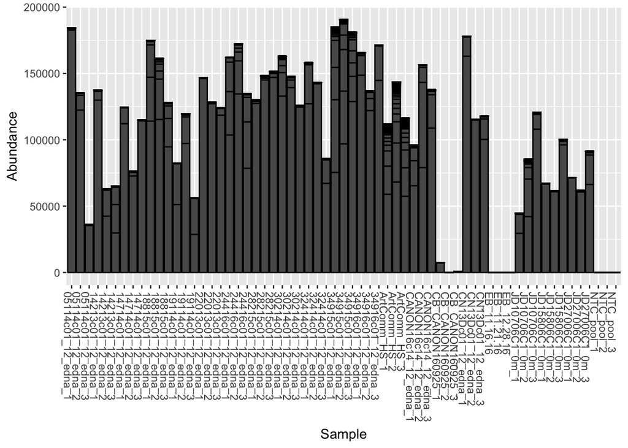

```r
plot_bar(p)
```

```r
plot_tree(p)
```

```
Error in plot_tree(p) :
  There is no phylogenetic tree in the object you have provided.
```

## Krona visualization

[figure not shown]

- [Home · marbl/Krona Wiki](https://github.com/marbl/Krona/wiki)
- [plot_krona: Interactive Taxonomy plot with Krona from a phyloseq object in cpauvert/psadd: Additions to phyloseq package for microbiome analysis](https://rdrr.io/github/cpauvert/psadd/man/plot_krona.html)
- [Bioconductor - metagenomeSeq](http://bioconductor.org/packages/release/bioc/html/metagenomeSeq.html)
- [Easy way to automatically save images of Krona HTML charts?](https://www.biostars.org/p/221964/)
- [GenomicaMicrob/OTUsamples2krona: Simple script to generate Krona charts for all samples in an OTU table file](https://github.com/GenomicaMicrob/OTUsamples2krona)
- [Qiime file for Krona pie chart?](https://www.biostars.org/p/191933/)
- [Visualize your metagenomics 16S results with Krona charts](https://ionreporter.thermofisher.com/ionreporter/help/GUID-BE5F627D-27BE-48E3-ACCF-6C8C1585CF92.html)
- [MetaPhlAn: Metagenomic Phylogenetic Analysis | The Huttenhower Lab](http://huttenhower.sph.harvard.edu/metaphlan)
- [gobics.de:Tax4Fun](http://tax4fun.gobics.de/)

## Shiny-phyloseq

- [Shiny-phyloseq](http://joey711.github.io/shiny-phyloseq/)

Install:

```r
install.packages("shiny")
shiny::runGitHub("shiny-phyloseq","joey711")
```

## Rockfish data

- [Marine Biodiversity Observation Network: Rockfish Recruitment and Ecosystem Assessment Survey](http://mbon.ioos.us/#module-metadata/8672e1f4-90df-4d9a-8533-37dbea59431e/2b5a4999-286b-4fd5-a4ba-fc3bef82b990)
  - [ERDDAP - Information about Rockfish Recruitment and Ecosystem Assessment Survey, Catch Data, from NOAA NMFS SWFSC FED](http://oceanview.pfeg.noaa.gov/erddap/info/FED_Rockfish_Catch/index.html)
    - [ERDDAP - Rockfish Recruitment and Ecosystem Assessment Survey, Catch Data - Data Access Form](http://oceanview.pfeg.noaa.gov/erddap/tabledap/FED_Rockfish_Catch.html)
      - FED_Rockfish_Catch_9330_bcea_28db.csv

```r
library(tidyverse)
csv = '../data/FED_Rockfish_Catch_9330_bcea_28db.csv'
d = read_csv(csv) # View(d)
d
```

```
## # A tibble: 5,655 x 28
##           `time (UTC)` `latitude (degrees_north)`
##                 <dttm>                      <dbl>
##  1 2015-06-07 04:41:17                    32.7097
##  2 2015-06-07 04:41:17                    32.7097
##  3 2015-06-07 04:41:17                    32.7097
##  4 2015-06-07 04:41:17                    32.7097
##  5 2015-06-07 04:41:17                    32.7097
##  6 2015-06-07 04:41:17                    32.7097
##  7 2015-06-07 04:41:17                    32.7097
##  8 2015-06-07 04:41:17                    32.7097
##  9 2015-06-07 04:41:17                    32.7097
## 10 2015-06-07 04:41:17                    32.7097
## # ... with 5,645 more rows, and 26 more variables: `longitude
## #   (degrees_east)` <dbl>, cruise <int>, haul_no <int>, vessel <chr>,
## #   station <int>, catch <int>, species_code <dbl>, common_name <chr>,
## #   sci_name <chr>, species_group <chr>, maturity <chr>,
## #   species_notes <chr>, aphiaid <int>, match_type <chr>, lsid <chr>,
## #   `station_latitude (degrees_north)` <dbl>, `station_longitude
## #   (degrees_east)` <dbl>, ctd_index <int>, `station_bottom_depth
## #   (meters)` <int>, area <chr>, strata <chr>, `tdr_depth (meters)` <int>,
## #   depth_strata <int>, `bottom_depth (meters)` <int>,
## #   station_active <chr>, station_notes <chr>
```

## Resources

- Literature on reproducible research best practices
  - [Our path to better science in less time using open data science tools](http://ohi-science.org/betterscienceinlesstime/)
  - [Good enough practices in scientific computing](http://journals.plos.org/ploscompbiol/article?id=10.1371/journal.pcbi.1005510#sec002)
  - Ten Simple Rules for the Care and Feeding of Scientific Data
  - [Best Practices for Scientific Computing](http://journals.plos.org/plosbiology/article?id=10.1371/journal.pbio.1001745&utm_content=buffer184f2&utm_medium=social&utm_source=twitter.com&utm_campaign=buffer)
- conference & training
  - [rstudio::conf](https://www.rstudio.com/conference/) Jan 31 - Feb 3, 2018 in San Diego
- [Training | EcoQuants](http://ecoquants.com/train/)
  - [Software Carpentry](http://remi-daigle.github.io/2016-04-15-UCSB/) workshop
  - [Environmental Informatics](http://ucsb-bren.github.io/env-info/) course
- Online books
  - [R for Data Science](http://r4ds.had.co.nz)
  - [Spatial Data Analysis and Modeling with R](http://rspatial.org)
  - [Geocomputation with R](http://robinlovelace.net/geocompr)